# R Notebook for Pease Replication 2015 PID

# Load libraries

```r
#install.packages("haven")
#install.packages("olsrr")
#install.packages("descriptr")
#install.packages("modelr")
#install.packages("tidyverse")
#install.packages("mosaic")
#install.packages("GGally")
#install.packages("psych")



library("tidyverse")
library("haven")
library(olsrr)
library(descriptr)
library(modelr)
library(tidyverse)
library(mosaic)
library(GGally)
library(psych)
```

# Read in the original datafiles

```r
# to print this chunk, but not execute it again once the files are imported, add: eval=FALSE


# use the haven package to read in the data -- we need the MIDUS II data and the biomarker project data
#midus2 <- read_spss("04652-0001-Data.sav")
#bio <- read_spss("29282-0001-Data.sav")

#saveRDS(midus2, "midus2.rds")
#saveRDS(bio, "bio.rds")
```

# Read in the saved datafiles

```r
midus2 <- readRDS("midus2.rds")
bio <- readRDS("bio.rds")
```

# Subset the datafiles

```r
#CREATE AND FILTER MIDUS2 DATASET

midus2.subset <- midus2 %>%
  filter(SAMPLMAJ == 1) %>%
  select(M2ID,
         B1PRSEX,
         B1PF7A,
         contains("B1SE6"),
         B1PAGE_M2,
         B1SE7I,
         B1SE7T,
         B1SE7BB,
         B1SE7EE,
         B1SNEURO,
         B1SEXTRA,
         B1SOPEN,
         B1SCONS2,
         B1SAGREE,
         B1SMPQAG) %>%
  filter(complete.cases(B1SNEURO,
                        B1SEXTRA,
                        B1SOPEN,
                        B1SCONS2,
                        B1SAGREE,
                        B1SMPQAG,
                        B1PRSEX,
                        B1PAGE_M2,
                        B1PF7A
                        )) %>%
  mutate(IN_MIDUS2 = 1)

#CREATE AND FILTER BIO SUBSET

bio.subset <- bio %>%
  select(M2ID,
         contains("B4Q4"),
         contains("B4Q5"),
         contains("B4Q6"),
         B4QTA_AG,
         B4QTA_AT,
         B4QTA_AR,
         B4QAE_AI,
         B4QAE_AO,
         B4QAE_AC,
         B4QAE_AA) %>%
  filter(complete.cases(B4QTA_AG,
                        B4QTA_AT,
                        B4QTA_AR,
                        B4QAE_AI,
                        B4QAE_AO,
                        B4QAE_AC,
                        B4QAE_AA)) %>%
  mutate(IN_BIO = 1)

combine <- left_join(midus2.subset, bio.subset, by = "M2ID") %>%
  select(M2ID,
         B1PF7A,
         B1SNEURO,
         B1SAGREE,
         B1SEXTRA,
         B1SOPEN,
         B1SCONS2,
         B4QTA_AG,
         B4QTA_AT,
         B4QTA_AR,
         B4QAE_AI,
         B4QAE_AO,
         B4QAE_AC,
         B4QAE_AA,
         B1SMPQAG,
         B1PF7A,
         B1PAGE_M2,
         B1PRSEX,
         everything())

combine
```

```
## # A tibble: 1,761 x 101
##     M2ID    B1PF7A  B1SNEURO  B1SAGREE  B1SEXTRA   B1SOPEN  B1SCONS2
##    <dbl> <dbl+lbl> <dbl+lbl> <dbl+lbl> <dbl+lbl> <dbl+lbl> <dbl+lbl>
##  1 10002         1      2.00       3.4       2.6     2.143       2.8
##  2 10019         1      1.50       3.6       3.4     3.143       3.0
##  3 10023         1      1.75       4.0       3.6     3.571       3.4
##  4 10039         8      1.75       3.8       3.0     3.571       3.2
##  5 10040         1      3.00       3.0       3.2     3.429       3.6
##  6 10042         1      1.75       4.0       3.2     3.714       4.0
##  7 10047         1      1.75       4.0       3.0     2.429       4.0
##  8 10050         1      3.00       4.0       2.8     3.714       3.6
##  9 10060         1      2.25       3.6       3.0     3.714       3.0
## 10 10061         1      1.75       3.2       2.4     3.000       3.6
## # ... with 1,751 more rows, and 94 more variables: B4QTA_AG <dbl+lbl>,
## #   B4QTA_AT <dbl+lbl>, B4QTA_AR <dbl+lbl>, B4QAE_AI <dbl+lbl>,
## #   B4QAE_AO <dbl+lbl>, B4QAE_AC <dbl+lbl>, B4QAE_AA <dbl+lbl>,
## #   B1SMPQAG <dbl+lbl>, B1PAGE_M2 <dbl+lbl>, B1PRSEX <dbl+lbl>,
## #   B1SE6A <dbl+lbl>, B1SE6B <dbl+lbl>, B1SE6C <dbl+lbl>,
## #   B1SE6D <dbl+lbl>, B1SE6E <dbl+lbl>, B1SE6F <dbl+lbl>,
## #   B1SE6G <dbl+lbl>, B1SE6H <dbl+lbl>, B1SE6I <dbl+lbl>,
## #   B1SE6J <dbl+lbl>, B1SE6K <dbl+lbl>, B1SE6L <dbl+lbl>,
## #   B1SE6M <dbl+lbl>, B1SE6N <dbl+lbl>, B1SE6O <dbl+lbl>,
## #   B1SE6P <dbl+lbl>, B1SE6Q <dbl+lbl>, B1SE6R <dbl+lbl>,
## #   B1SE6S <dbl+lbl>, B1SE6T <dbl+lbl>, B1SE6U <dbl+lbl>,
## #   B1SE6V <dbl+lbl>, B1SE6W <dbl+lbl>, B1SE6X <dbl+lbl>,
## #   B1SE6Y <dbl+lbl>, B1SE6Z <dbl+lbl>, B1SE6AA <dbl+lbl>,
## #   B1SE6BB <dbl+lbl>, B1SE6CC <dbl+lbl>, B1SE6DD <dbl+lbl>,
## #   B1SE6EE <dbl+lbl>, B1SE7I <dbl+lbl>, B1SE7T <dbl+lbl>,
## #   B1SE7BB <dbl+lbl>, B1SE7EE <dbl+lbl>, IN_MIDUS2 <dbl>,
## #   B4Q4A <dbl+lbl>, B4Q4B <dbl+lbl>, B4Q4C <dbl+lbl>, B4Q4D <dbl+lbl>,
## #   B4Q4E <dbl+lbl>, B4Q4F <dbl+lbl>, B4Q4G <dbl+lbl>, B4Q4H <dbl+lbl>,
## #   B4Q4I <dbl+lbl>, B4Q4J <dbl+lbl>, B4Q5A <dbl+lbl>, B4Q5B <dbl+lbl>,
## #   B4Q5C <dbl+lbl>, B4Q5D <dbl+lbl>, B4Q5E <dbl+lbl>, B4Q5F <dbl+lbl>,
## #   B4Q5G <dbl+lbl>, B4Q5H <dbl+lbl>, B4Q5I <dbl+lbl>, B4Q5J <dbl+lbl>,
## #   B4Q5K <dbl+lbl>, B4Q5L <dbl+lbl>, B4Q5M <dbl+lbl>, B4Q5N <dbl+lbl>,
## #   B4Q5O <dbl+lbl>, B4Q5P <dbl+lbl>, B4Q5Q <dbl+lbl>, B4Q5R <dbl+lbl>,
## #   B4Q5S <dbl+lbl>, B4Q5T <dbl+lbl>, B4Q5U <dbl+lbl>, B4Q5V <dbl+lbl>,
## #   B4Q6A <dbl+lbl>, B4Q6B <dbl+lbl>, B4Q6C <dbl+lbl>, B4Q6D <dbl+lbl>,
## #   B4Q6E <dbl+lbl>, B4Q6F <dbl+lbl>, B4Q6G <dbl+lbl>, B4Q6H <dbl+lbl>,
## #   B4Q6I <dbl+lbl>, B4Q6J <dbl+lbl>, B4Q6K <dbl+lbl>, B4Q6L <dbl+lbl>,
## #   B4Q6M <dbl+lbl>, B4Q6N <dbl+lbl>, B4Q6O <dbl+lbl>, IN_BIO <dbl>
```

# create dataset for analysis

```r
# note which variables are categorical and numeric and tidy things up

analyze <- combine

all.vars <- names(analyze)
cat.vars <- c("M2ID", "B1PF7A")


##Note this needs o be done because we originally read in data from spss files, r doesn't like the spss files.

analyze <- analyze %>%
  mutate_at(vars(all.vars), funs(as.numeric)) %>%
  mutate_at(vars(cat.vars), funs(as.factor)) %>%
  mutate(GENDER = factor(B1PRSEX, levels = c("1", "2"), labels = c("male", "female"))) %>%
  mutate(MALE = B1PRSEX - 1) %>%
  select(-B1PRSEX)


# create subset of just variable scale scores and the demographic variables
analyze <- analyze %>%
  select(B1SNEURO, B1SAGREE, B1SEXTRA, B1SOPEN, B1SCONS2,
         B4QTA_AG, B4QTA_AT, B4QTA_AR, B4QAE_AI, B4QAE_AO, B4QAE_AC,
         B1SMPQAG,
         B1PF7A,
         B1PAGE_M2, B4QAE_AA,
         GENDER, MALE) %>%
  filter(complete.cases(B1SNEURO, B1SAGREE, B1SEXTRA, B1SOPEN, B1SCONS2,
         B4QAE_AA))



analyze
```

```
## # A tibble: 627 x 17
##    B1SNEURO B1SAGREE B1SEXTRA B1SOPEN B1SCONS2 B4QTA_AG B4QTA_AT B4QTA_AR
##       <dbl>    <dbl>    <dbl>   <dbl>    <dbl>    <dbl>    <dbl>    <dbl>
##  1     2.00      3.4      2.6   2.143      2.8       21        4        6
##  2     1.50      3.6      3.4   3.143      3.0       26        4       11
##  3     3.00      3.0      3.2   3.429      3.6       20        4        6
##  4     1.75      4.0      3.0   2.429      4.0       27        7        8
##  5     2.25      3.6      3.0   3.714      3.0       24        4        8
##  6     1.75      3.2      2.4   3.000      3.6       22        5        8
##  7     2.00      2.8      3.0   2.857      3.0       24        4        7
##  8     2.25      2.4      1.8   2.714      3.2       24        6        7
##  9     1.50      3.2      2.6   3.714      4.0       25        4        8
## 10     2.25      4.0      2.0   1.429      4.0       16        4        4
## # ... with 617 more rows, and 9 more variables: B4QAE_AI <dbl>,
## #   B4QAE_AO <dbl>, B4QAE_AC <dbl>, B1SMPQAG <dbl>, B1PF7A <fctr>,
## #   B1PAGE_M2 <dbl>, B4QAE_AA <dbl>, GENDER <fctr>, MALE <dbl>
```

# Explore simple linear regression and correlation

## Anger Expression Adjustment scale description

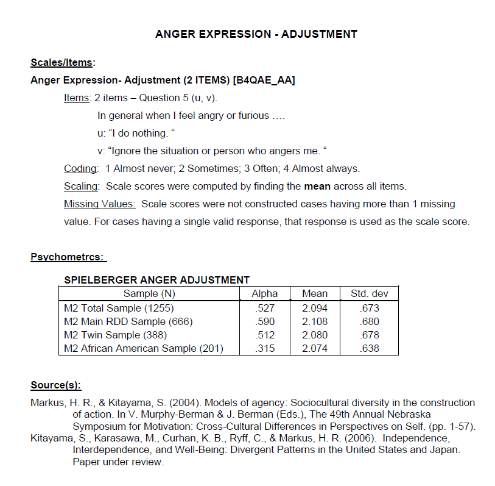

## Create a correlation matrix of Anger Expression Adjustment and the big 5 personality scales

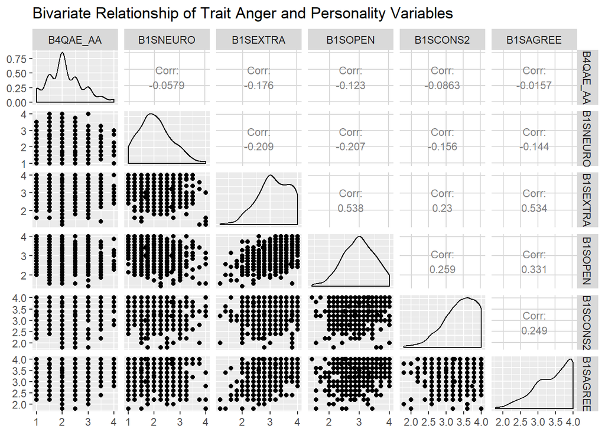

```r
scatterplot <- ggpairs(analyze,
                       columns = c("B4QAE_AA", "B1SNEURO", "B1SEXTRA", "B1SOPEN", "B1SCONS2", "B1SAGREE"),
                       upper = list(continuous = wrap("cor", size=3)),
        title = "Bivariate Relationship of Trait Anger and Personality Variables")
print(scatterplot, progress=FALSE )
```

We selected to look into Openess and its relationship with anger Expression adjustment based off of our its correlateion of -0.123 and our interest in how the two would relate.

Here are the descriptives fro opennesss from the *MIDUSII* codebook:

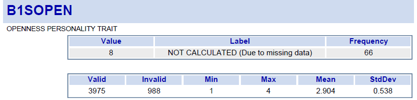

## Descriptive Statistics of predictor and outcome variables

### Anger Expression Adjustment (outcome)

```r
myvars <- analyze %>%
  select(B4QAE_AA, B1SOPEN) %>%
  na.omit()


summary_stats(myvars$B4QAE_AA)
```

```
##                        Univariate Analysis
##
##  N                     627.00      Variance                0.46
##  Missing                 0.00      Std Deviation           0.68
##  Mean                    2.10      Range                   3.00
##  Median                  2.00      Interquartile Range     1.00
##  Mode                    2.00      Uncorrected SS       3057.25
##  Trimmed Mean            2.07      Corrected SS          288.82
##  Skewness                0.51      Coeff Variation        32.33
##  Kurtosis                0.09      Std Error Mean          0.03
##
##                              Quantiles
##
##              Quantile                            Value
##
##             Max                                  4.00
##             99%                                  4.00
##             95%                                  3.00
##             90%                                  3.50
##             Q3                                   2.50
##             Median                               2.00
##             Q1                                   1.50
##             10%                                  1.50
##             5%                                   1.00
##             1%                                   1.00
##             Min                                  1.00
##
##                            Extreme Values
##
##                 Low                              High
##
##   Obs                       Value       Obs                       Value
##   30                          1         17                          4
##   37                          1         119                         4
##   38                          1         125                         4
##   70                          1         130                         4
##   76                          1         142                         4
```

### Openness (Predictor)

```r
summary_stats(myvars$B1SOPEN)
```

```
##                         Univariate Analysis
##
##  N                      627.00      Variance                 0.27
##  Missing                  0.00      Std Deviation            0.52
##  Mean                     2.99      Range                    2.57
##  Median                   3.00      Interquartile Range      0.86
##  Mode                     3.00      Uncorrected SS        5766.27
##  Trimmed Mean             3.00      Corrected SS           170.80
##  Skewness                -0.18      Coeff Variation         17.49
##  Kurtosis                -0.33      Std Error Mean           0.02
##
##                               Quantiles
##
##               Quantile                            Value
##
##              Max                                   4.00
##              99%                                   4.00
##              95%                                   3.71
##              90%                                   3.86
##              Q3                                    3.43
##              Median                                3.00
##              Q1                                    2.57
##              10%                                   2.29
##              5%                                    2.14
##              1%                                    1.71
##              Min                                   1.43
##
##                             Extreme Values
##
##                 Low                                High
##
##   Obs                        Value       Obs                        Value
##   10                         1.429       26                           4
##   53                         1.571       62                           4
##   173                        1.571       103                          4
##   381                        1.571       111                          4
##   401                        1.571       207                          4
```

## Set hypotheses

I am interested in assessing the relationship between Openness and ANGER EXPRESSION - ADJUSTMENT. In this case, I am not particularly interested in a significance test for the intercept, it’s the slope that is of interest. I will state a null and alternative hypothesis for the slope.

Ho: B1 = 0 Ha: B1 ne 0

## Set alpha and obtain the critical value of t

```r
qt(c(.025, .975), df=625)
```

```
## [1] -1.963767  1.963767
```

## Center Openness at the mean and then fit the SLR

```r
#Centering opennes vatiable
myvars <- myvars %>%
  mutate(B1SOPEN_m = B1SOPEN - mean(B1SOPEN))

my_model <- lm(B4QAE_AA ~ B1SOPEN_m, data = myvars)

ols_regress(my_model)
```

```
##                         Model Summary
## --------------------------------------------------------------
## R                       0.123       RMSE                0.675
## R-Squared               0.015       Coef. Var          32.105
## Adj. R-Squared          0.014       MSE                 0.455
## Pred R-Squared          0.009       MAE                 0.525
## --------------------------------------------------------------
##  RMSE: Root Mean Square Error
##  MSE: Mean Square Error
##  MAE: Mean Absolute Error
##
##                                ANOVA
## -------------------------------------------------------------------
##                Sum of
##               Squares         DF    Mean Square      F        Sig.
## -------------------------------------------------------------------
## Regression      4.374          1          4.374    9.612    0.0020
## Residual      284.445        625          0.455
## Total         288.819        626
## -------------------------------------------------------------------
##
##                                   Parameter Estimates
## ----------------------------------------------------------------------------------------
##       model      Beta    Std. Error    Std. Beta      t        Sig      lower     upper
## ----------------------------------------------------------------------------------------
## (Intercept)     2.101         0.027                 77.993    0.000     2.048     2.154
##   B1SOPEN_m    -0.160         0.052       -0.123    -3.100    0.002    -0.261    -0.059
## ----------------------------------------------------------------------------------------
```

### Interpretation

The intercept is 2.101, this is the predicted Anger Expression Adjustment score for individuals with an average level of openness. The slope is -0.160, this is the expected change in Anger Expression Adjustment for a one unit increase in Openness.

The estimate of the slope divided by the associated standard error gives t-star, that is t-star = -0.160/.052 =-3.100. This means that our estimate of the slope is -3.100 standard errors away from the asserted null hypothesis (0). If the null hypothesis were true, we would expect about 95% of the random samples to produce an estimate of the slope that is within 1.96 standard errors of 0. Therefore it is highly unlikely that the null hypothesis is true given this estimate of the slope. In fact, the p-value is .002, which provides the probability that we would obtain a t-star of this magnitude or larger if the null hypothesis were true. Therefore, we reject the null hypothesis.

### Create scatterplot of Openness and Anger Expression Adjustment with fitted model

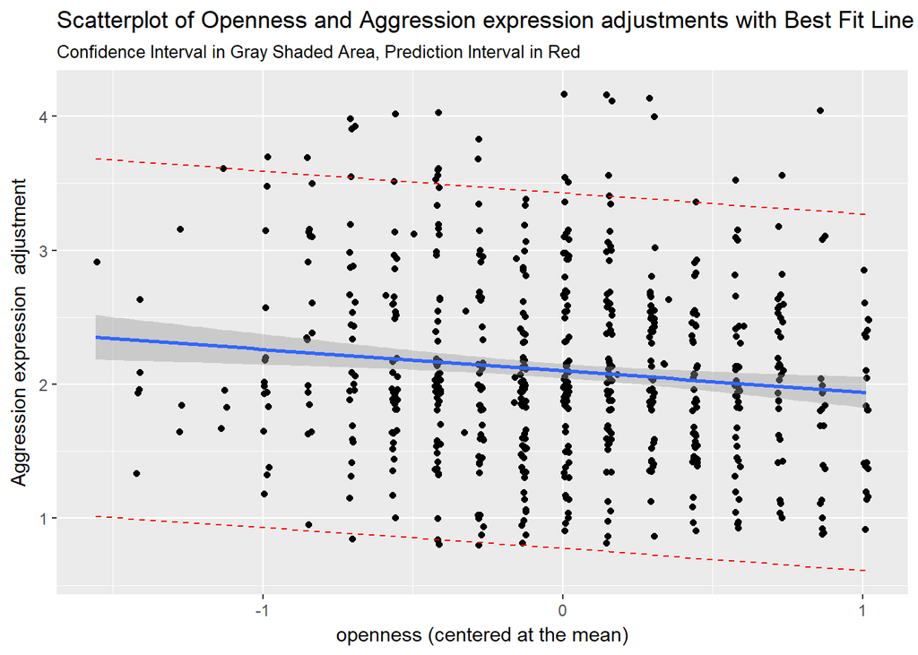

```r
temp_var <- predict(my_model, myvars, interval="prediction")
myvars_new <- cbind(temp_var, myvars)


ggplot(myvars_new, aes(x = B1SOPEN_m, y =B4QAE_AA)) +
  geom_jitter() +
  geom_smooth(method = "lm", se = TRUE) +
  geom_line(aes(y=lwr), color = "red", linetype = "dashed") +
  geom_line(aes(y=upr), color = "red", linetype = "dashed") +
  labs(title = "Scatterplot of Openness and Aggression expression adjustments with Best Fit Line",
       subtitle = "Confidence Interval in Gray Shaded Area, Prediction Interval in Red",
       x = "openness (centered at the mean)", y = "Aggression expression  adjustment")
```

### Residuals plot

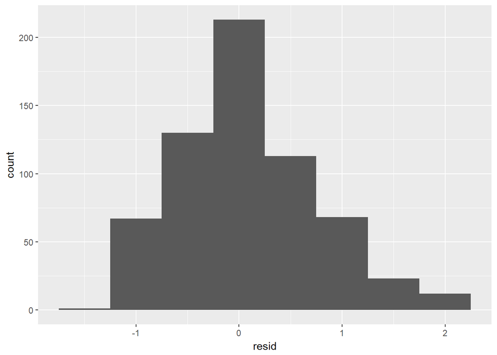

```r
myvars <- myvars %>%
  add_residuals(my_model)

ggplot(myvars, aes(x = resid)) + geom_histogram(binwidth = .5)
```

Our residual plot is relatively normally distributed.